# Homework 3

### View it online: http://acsweb.ucsd.edu/~djc035/Assignment3.html

# Objective

How do we find clusters of palindromes? How do we determine whether a cluster is just a chance occurrence or a potential replication site?

## 1.

**Locations:** Here the goal is to graphically compare your sample palindrome locations to random uniform scatter. To do this, you can visualize the distribution of your sample, the distributions of random uniform scatter instances, and the theoretical uniform distribution. You can visualize the distributions using either histograms or empirical cdfs. Be sure to simulate the random uniform scatter several times (at least 5 times). This is sufficient for the [Random Scatter] section in the homework prompt.

```r
#read in "hcmv.txt" into data
data <- read.table("hcmv.txt", header=TRUE)
head(data)
```

```
##   location
## 1      177
## 2     1321
## 3     1433
## 4     1477
## 5     3248
## 6     3255
```

```r
nrow(data)
```

```
## [1] 296
```

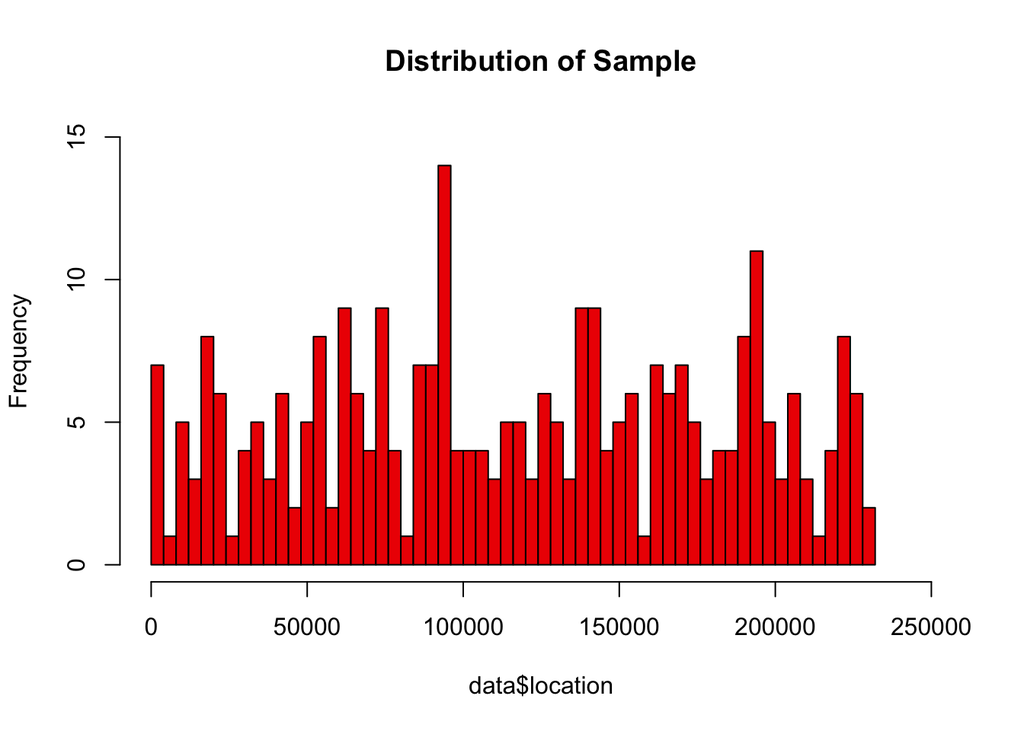

```r
hist(data$location, xlim=c(0,250000), ylim=c(0,15), breaks=seq(0,232000, by=4000), col='red2', main="Distribution of Sample")
```

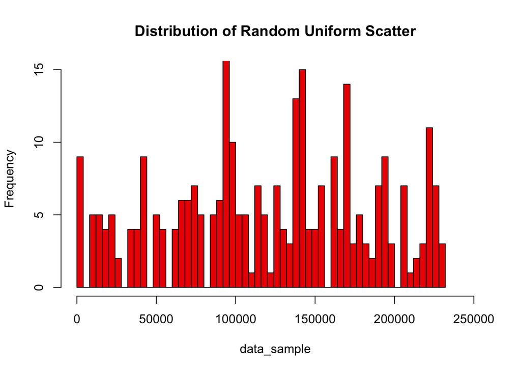

```r
set.seed(100)
data_sample = sample(x=data$location, size=296, replace=TRUE)
hist(data_sample, xlim=c(0,250000), ylim=c(0,15), breaks=seq(0,232000, by=4000), col='red2', main="Distribution of Random Uniform Scatter")
```

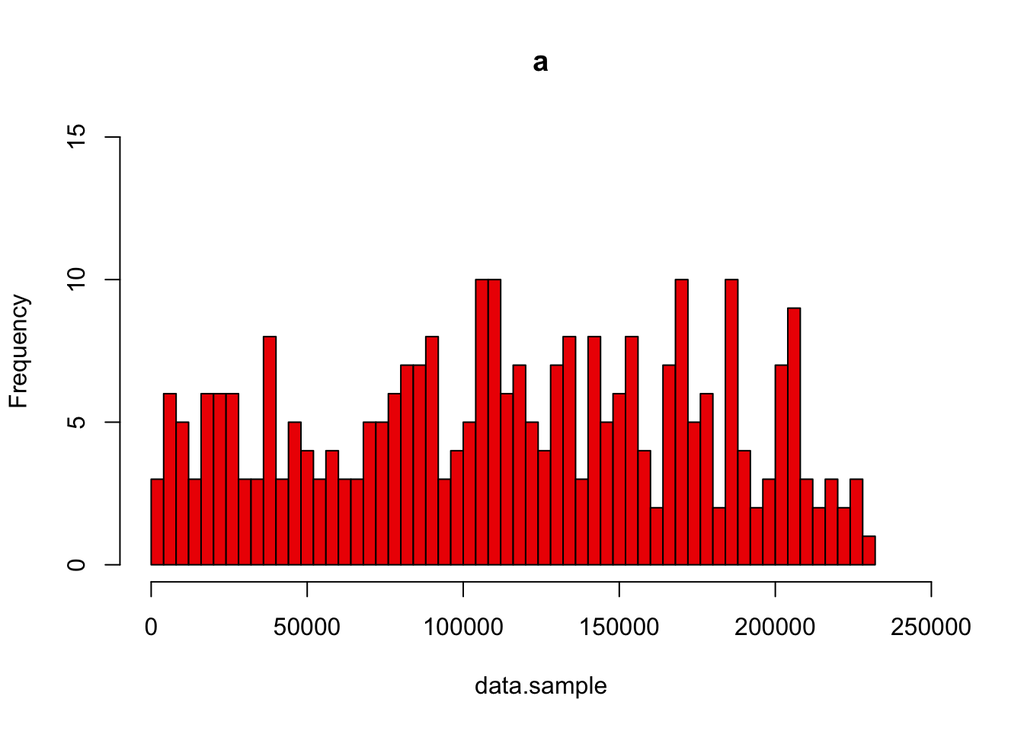

```r
N <- max(data$location, na.rm=TRUE)
n <- 296
gene <- seq(177, N)

set.seed(200)
data.sample <- sample.int(N, size=n, replace=FALSE)
aHistogram = hist(data.sample, xlim=c(0,250000), ylim=c(0,15), breaks=seq(0,232000, by=4000), col='red2', main="a")
```

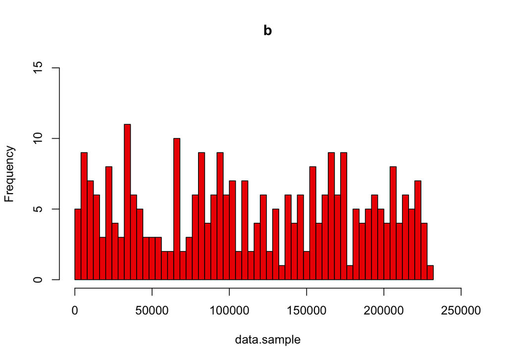

```r
data.sample <- sample.int(N, size=n, replace=FALSE)
bHistogram = hist(data.sample, xlim=c(0,250000), ylim=c(0,15), breaks=seq(0,232000, by=4000), col='red2', main="b")
```

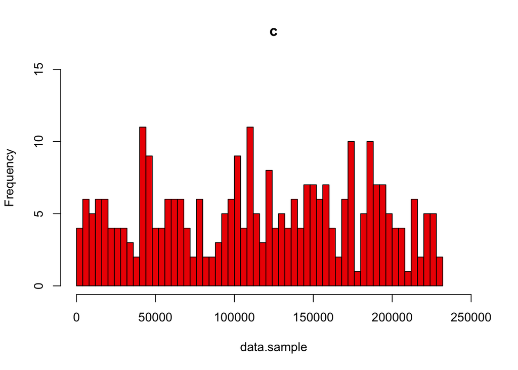

```r
data.sample <- sample.int(N, size=n, replace=FALSE)
cHistogram = hist(data.sample, xlim=c(0,250000), ylim=c(0,15), breaks=seq(0,232000, by=4000), col='red2', main="c")
```

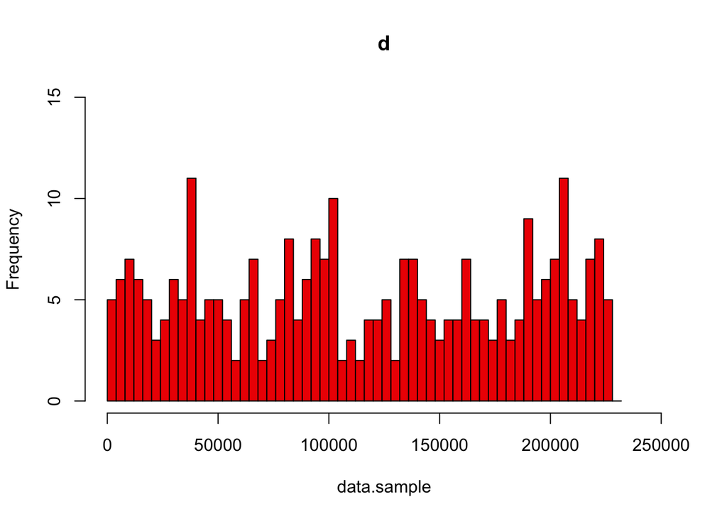

```r
data.sample <- sample.int(N, size=n, replace=FALSE)
dHistogram = hist(data.sample, xlim=c(0,250000), ylim=c(0,15), breaks=seq(0,232000, by=4000), col='red2', main="d")
```

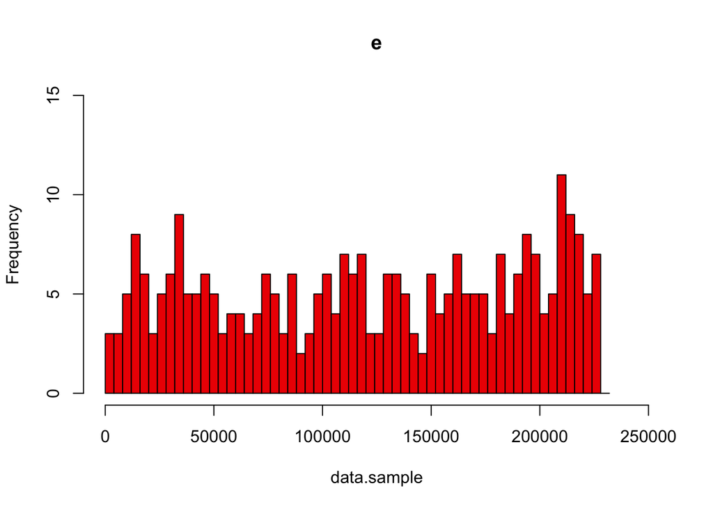

```r
data.sample <- sample.int(N, size=n, replace=FALSE)
eHistogram = hist(data.sample, xlim=c(0,250000), ylim=c(0,15), breaks=seq(0,232000, by=4000), col='red2', main="e")
```

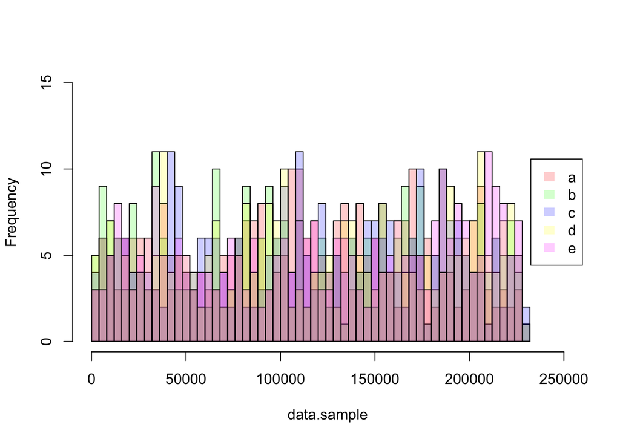

```r
aHistColor = rgb(1,0,0,0.2)
bHistColor = rgb(0,1,0,0.2)
cHistColor = rgb(0,0,1,0.2)
dHistColor = rgb(1,1,0,0.2)
eHistColor = rgb(1,0,1,0.2)

plot(aHistogram, col=aHistColor, ylim=c(0,15), xlim=c(0,250000), main=NA)
plot(bHistogram, col=bHistColor, ylim=c(0,15), xlim=c(0,250000), add=T)
plot(cHistogram, col=cHistColor, ylim=c(0,15), xlim=c(0,250000), add=T)
plot(dHistogram, col=dHistColor, ylim=c(0,15), xlim=c(0,250000), add=T)
plot(eHistogram, col=eHistColor, ylim=c(0,15), xlim=c(0,250000), add=T)

legend('right', c('a', 'b', 'c', 'd', 'e'), fill=c(aHistColor, bHistColor, cHistColor, dHistColor, eHistColor), border=NA)
```

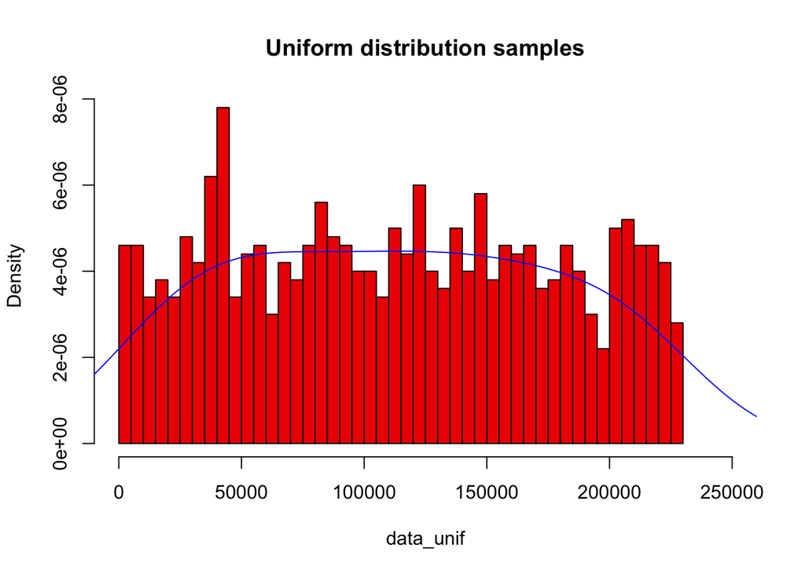

```r
set.seed(2017)
n <- 1000
data_unif <- runif(n, min=177, max=228953)
hist(data_unif, xlim=c(0,250000), breaks=58, probability=TRUE, col='red2', main = "Uniform distribution samples")
lines(density(data_unif, adjust=2), col=4)
```

## 2.

**Spacings:** Here the goal is to graphically examine the distribution of your sample spacings. There are 3 types of spacings to examine: spacings between consecutive palindromes, spacings between palindromes with one in between (i.e. sums of pairs of consecutive spacings), and spacings between palindromes with two in between (i.e. sums of triplets of consecutive spacings). Next, you can graphically compare these 3 types of spacings to those that come from random uniform scatter (using empirical cdf or histograms). Again, you should simulate at least 5 random uniform scatters. Lastly, using theoretical results discussed in lecture, identify the theoretical distributions of the spacings from random uniform scatter (you won’t be expected to know the distribution for the sums of consecutive triplets but it shouldn’t be too hard to intuit). Overlay these theoretical distributions as a cdf or density on your plots.

### 2a)

Examine 3 types of spacings by plotting histograms

```r
space_1 = data.frame(diff(as.matrix(data)))
head(space_1)
```

```
##   location
## 1     1144
## 2      112
## 3       44
## 4     1771
## 5        7
## 6       31
```

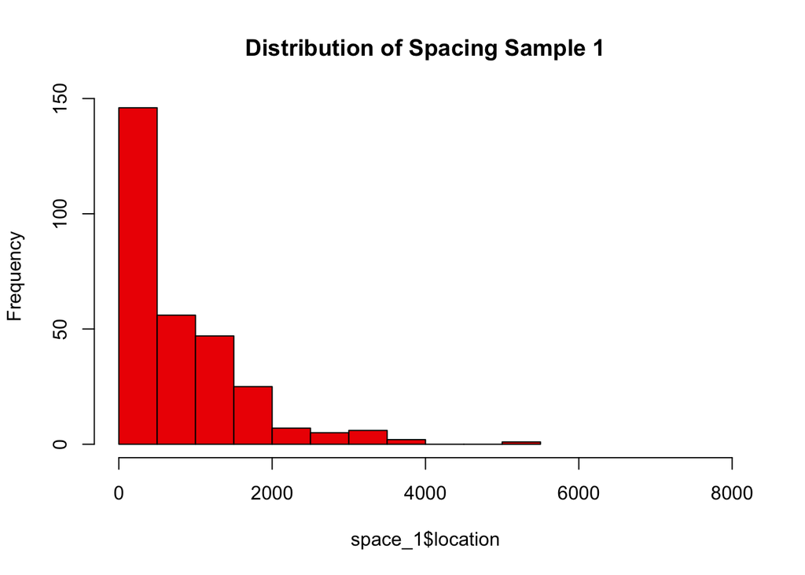

```r
hist_1 = hist(space_1$location, xlim=c(0,8000), breaks=16, col='red2', main="Distribution of Spacing Sample 1")
```

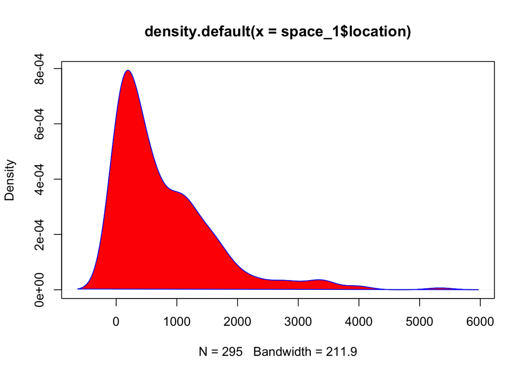

```r
d1 <- density(space_1$location) # returns the density data
plot(d1) # plots the results
polygon(d1, col="red", border="blue")
```

```r
library(zoo)
space_2 = rollapply(space_1, 2, sum)
head(space_2)
```

```
##      location
## [1,]     1256
## [2,]      156
## [3,]     1815
## [4,]     1778
## [5,]       38
## [6,]     4008
```

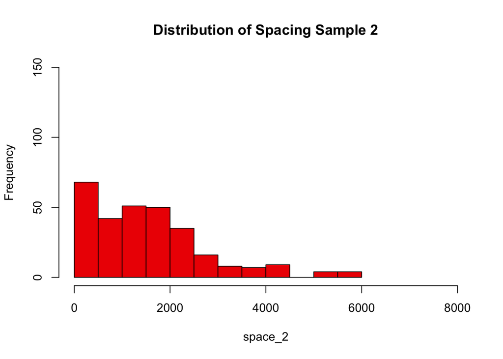

```r
hist_2 = hist(space_2, xlim=c(0,8000), ylim=c(0,150), breaks=16, col='red2', main="Distribution of Spacing Sample 2")
```

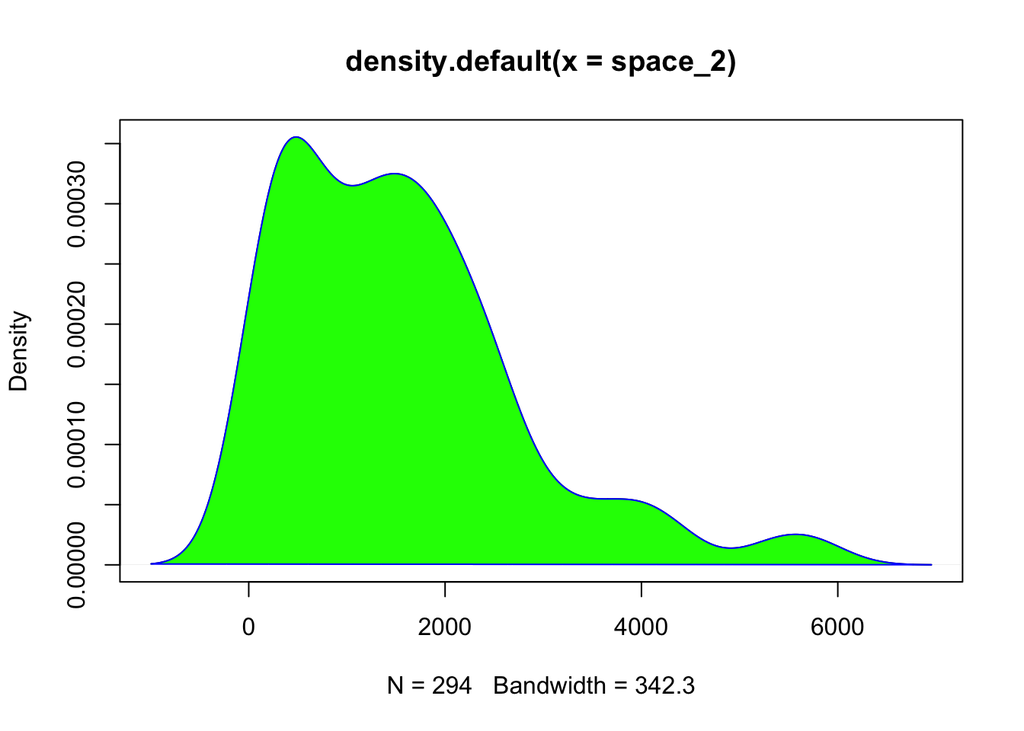

```r
d2 <- density(space_2) # returns the density data
plot(d2) # plots the results
polygon(d2, col="green", border="blue")
```

```r
library(zoo)
space_3 = rollapply(space_1, 3, sum)
head(space_3)
```

```
##      location
## [1,]     1300
## [2,]     1927
## [3,]     1822
## [4,]     1809
## [5,]     4015
## [6,]     5768
```

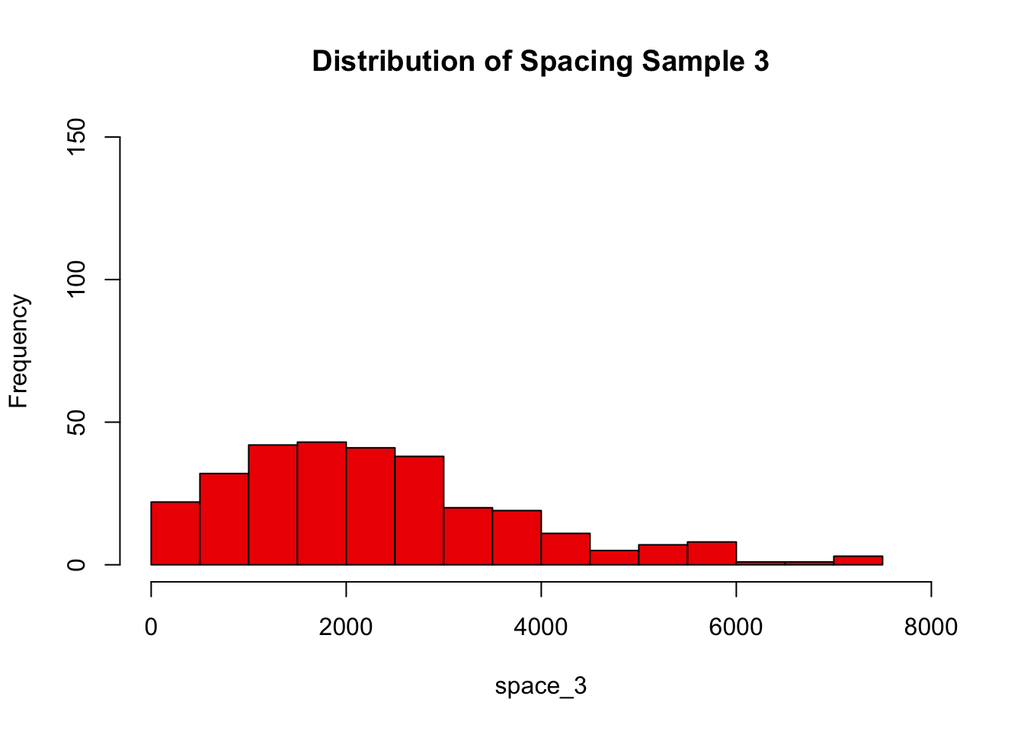

```r
hist_3 = hist(space_3, xlim=c(0,8000), ylim=c(0,150), breaks=16, col='red2', main="Distribution of Spacing Sample 3")
```

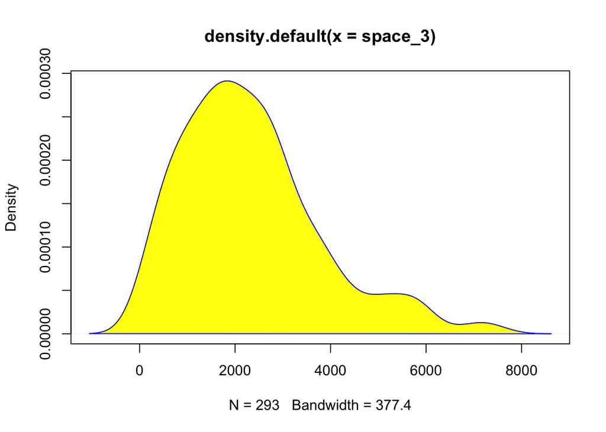

```r
d3 <- density(space_3) # returns the density data
plot(d3) # plots the results
polygon(d3, col="yellow", border="blue")
```

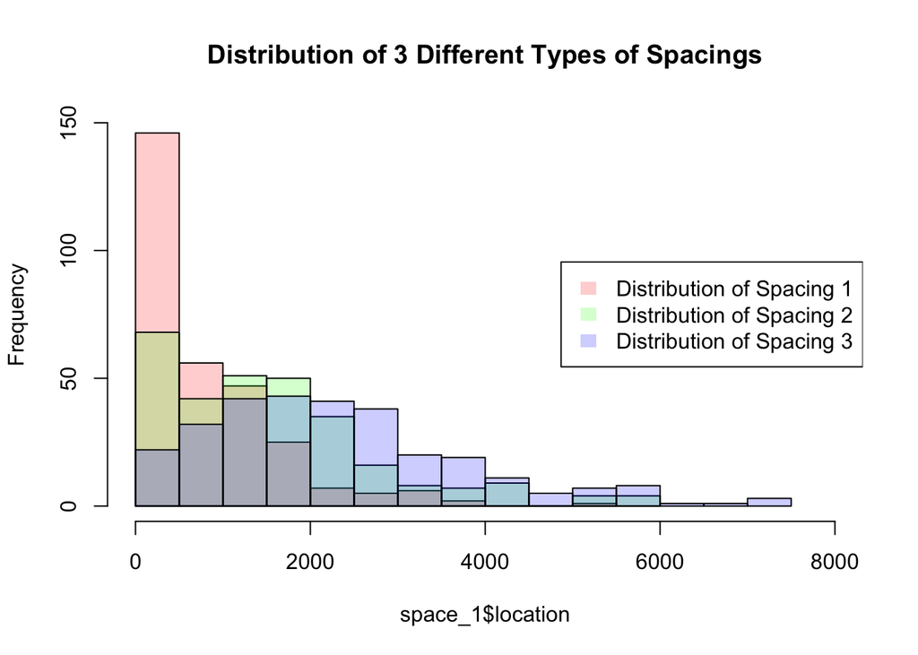

```r
space1HistColor = rgb(1,0,0,0.2)
space2HistColor = rgb(0,1,0,0.2)
space3HistColor = rgb(0,0,1,0.2)

plot(hist_1, col=space1HistColor, ylim=c(0,150), xlim=c(0,8000), main="Distribution of 3 Different Types of Spacings")
plot(hist_2, col=space2HistColor, ylim=c(0,150), xlim=c(0,8000), add=T)
plot(hist_3, col=space3HistColor, ylim=c(0,150), xlim=c(0,8000), add=T)


legend('right', c('Distribution of Spacing 1', 'Distribution of Spacing 2', 'Distribution of Spacing 3'), fill=c(aHistColor, bHistColor, cHistColor, dHistColor, eHistColor), border=NA)
```

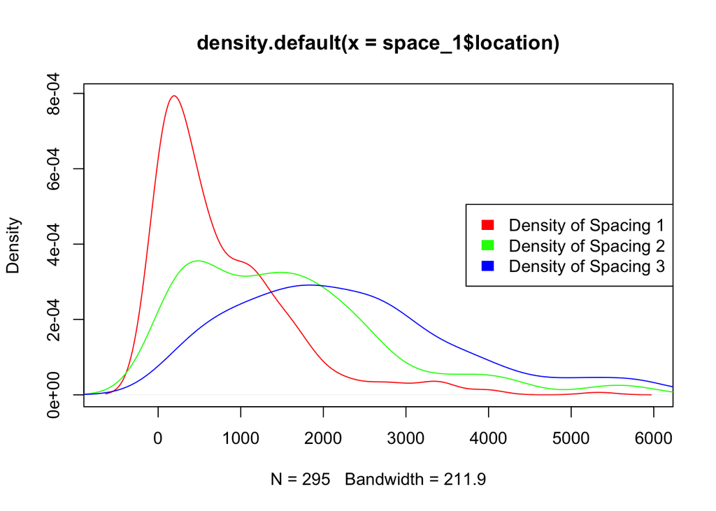

```r
#density plot comparison

plot(d1, col="red")
lines(d2, col="green")
lines(d3, col="blue")
legend('right',c('Density of Spacing 1', 'Density of Spacing 2', 'Density of Spacing 3'),
fill=c("red","green","blue"),border=NA)
```

### 2b)

Plot 5x3 histograms of the random uniform scatters (5 random uniform scatters, 3 types of spacings for each)

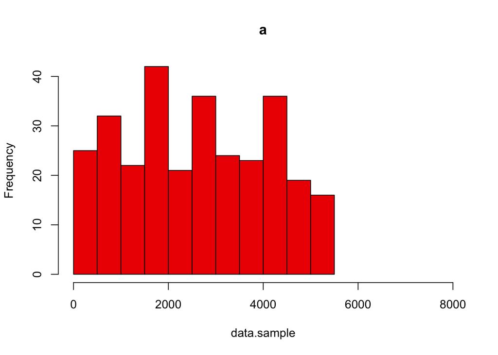

```r
N <- max(space_1$location, na.rm=TRUE)
n <- 296
gene <- seq(min(space_1$location, na.rm=TRUE), N)

set.seed(200)
data.sample <- sample.int(N, size=n, replace=FALSE)
aHistogram = hist(data.sample, xlim=c(0,8000), breaks=16, col='red2', main="a")
```

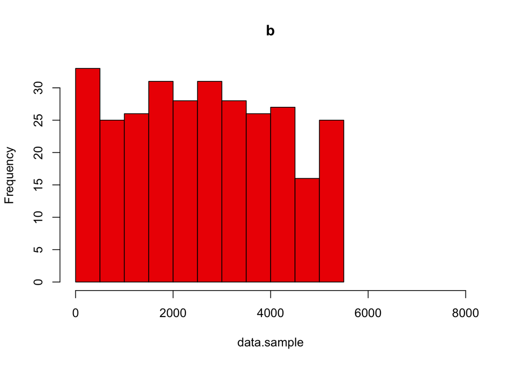

```r
data.sample <- sample.int(N, size=n, replace=FALSE)
bHistogram = hist(data.sample, xlim=c(0,8000), breaks=16, col='red2', main="b")
```

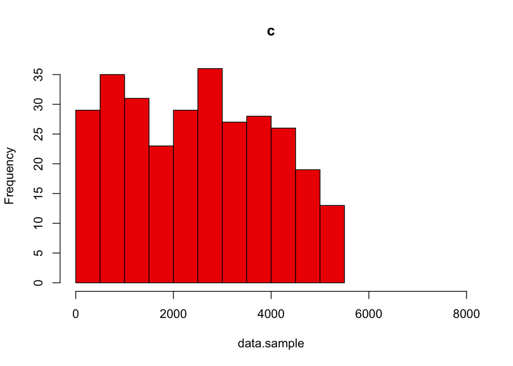

```r
data.sample <- sample.int(N, size=n, replace=FALSE)
cHistogram = hist(data.sample, xlim=c(0,8000), breaks=16, col='red2', main="c")
```

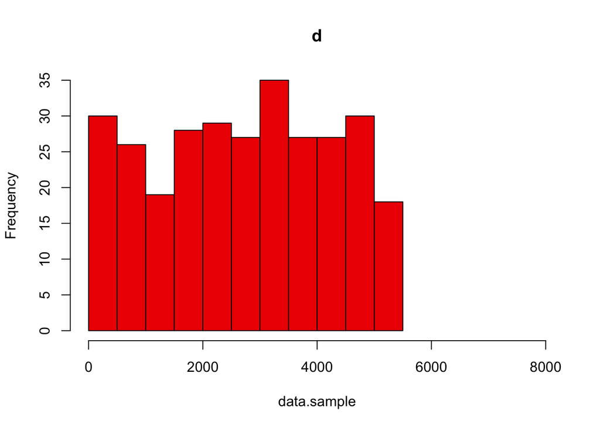

```r
data.sample <- sample.int(N, size=n, replace=FALSE)
dHistogram = hist(data.sample, xlim=c(0,8000), breaks=16,col='red2', main="d")
```

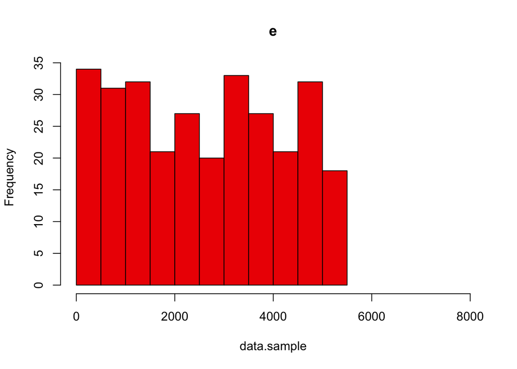

```r
data.sample <- sample.int(N, size=n, replace=FALSE)
eHistogram = hist(data.sample, xlim=c(0,8000), breaks=16, col='red2', main="e")
```

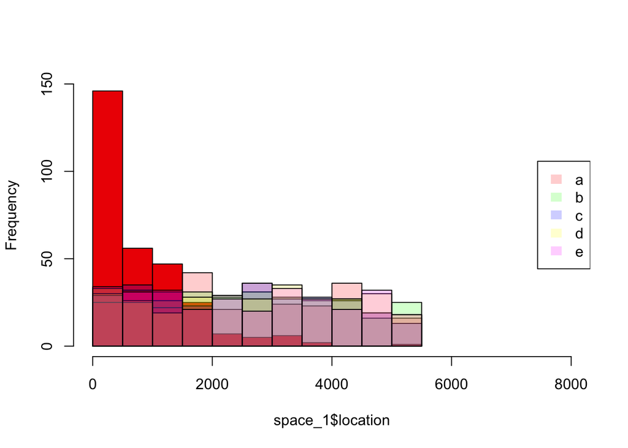

```r
aHistColor = rgb(1,0,0,0.2)
bHistColor = rgb(0,1,0,0.2)
cHistColor = rgb(0,0,1,0.2)
dHistColor = rgb(1,1,0,0.2)
eHistColor = rgb(1,0,1,0.2)

plot(hist_1, col='red2', ylim=c(0,150), xlim=c(0,8000), main=NA)
plot(aHistogram, col=aHistColor, ylim=c(0,150), xlim=c(0,8000), add=T)
plot(bHistogram, col=bHistColor, ylim=c(0,150), xlim=c(0,8000), add=T)
plot(cHistogram, col=cHistColor, ylim=c(0,150), xlim=c(0,8000), add=T)
plot(dHistogram, col=dHistColor, ylim=c(0,150), xlim=c(0,8000), add=T)
plot(eHistogram, col=eHistColor, ylim=c(0,150), xlim=c(0,8000), add=T)


legend('right', c('a', 'b', 'c', 'd', 'e'), fill=c(aHistColor, bHistColor, cHistColor, dHistColor, eHistColor), border=NA)
```

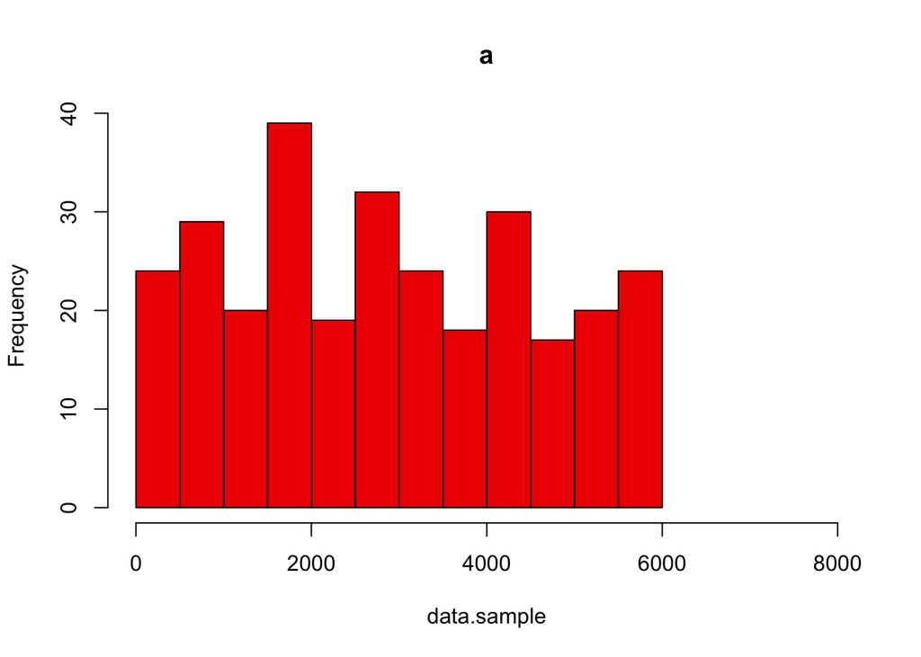

```r
N <- max(space_2, na.rm=TRUE)
n <- 296
gene <- seq(min(space_2, na.rm=TRUE), N)

set.seed(200)
data.sample <- sample.int(N, size=n, replace=FALSE)
aHistogram = hist(data.sample, xlim=c(0,8000), breaks=16, col='red2', main="a")
```

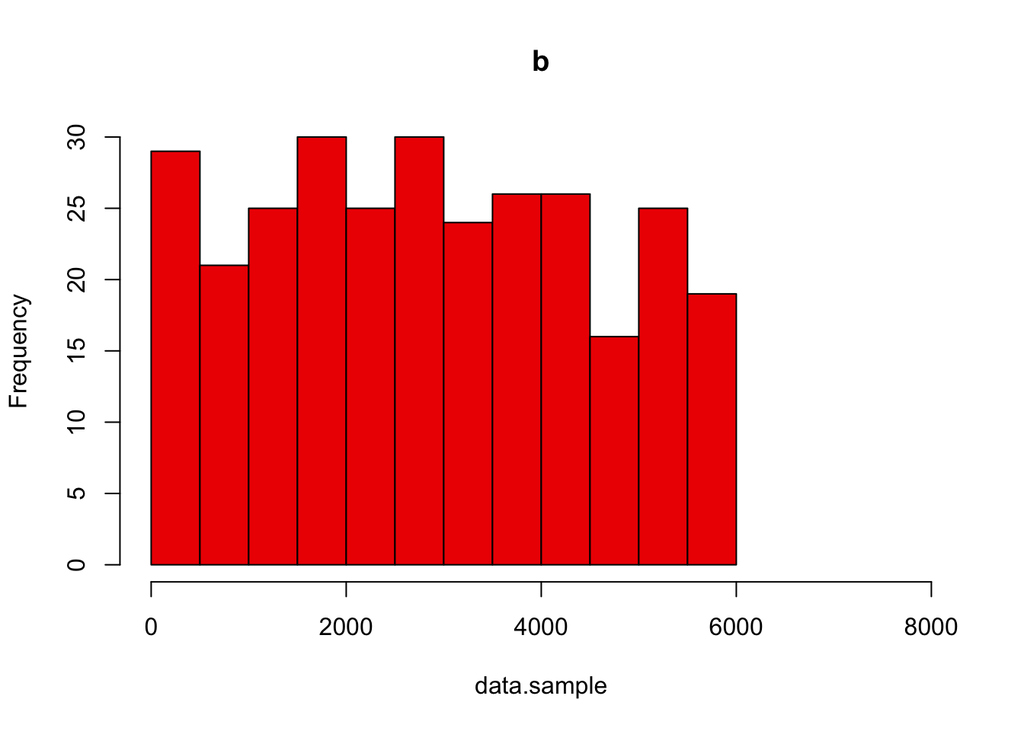

```r
data.sample <- sample.int(N, size=n, replace=FALSE)
bHistogram = hist(data.sample, xlim=c(0,8000), breaks=16, col='red2', main="b")
```

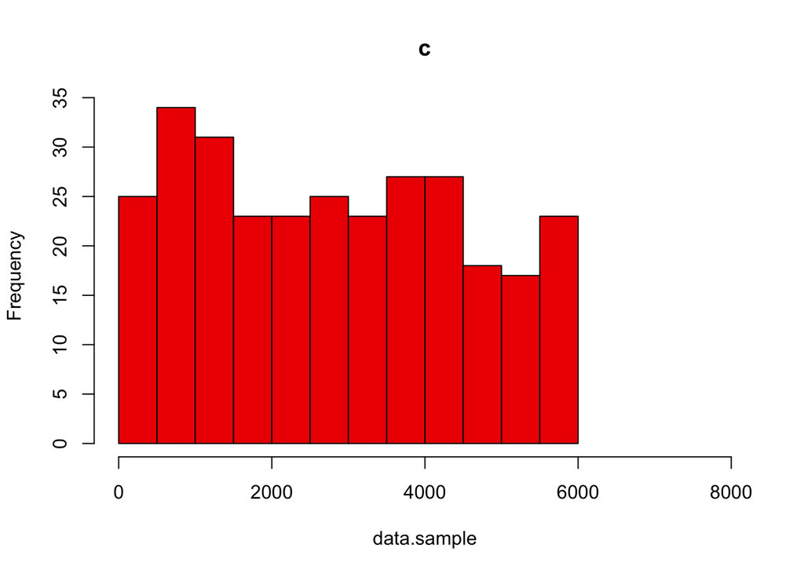

```r
data.sample <- sample.int(N, size=n, replace=FALSE)
cHistogram = hist(data.sample, xlim=c(0,8000), breaks=16, col='red2', main="c")
```

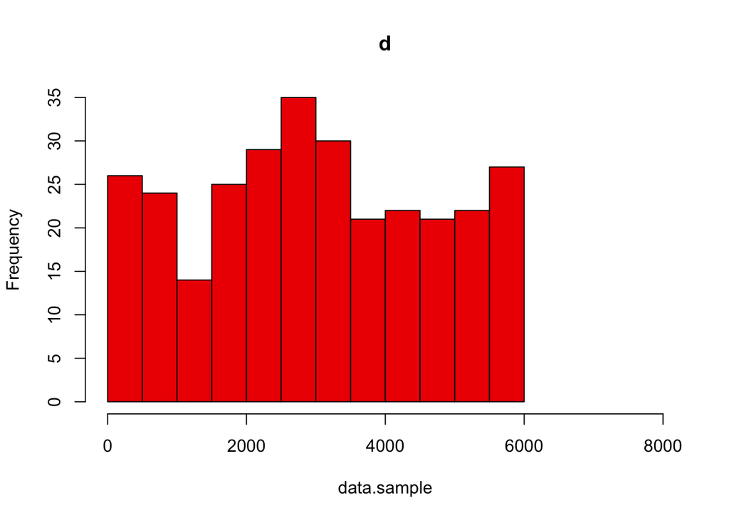

```r
data.sample <- sample.int(N, size=n, replace=FALSE)
dHistogram = hist(data.sample, xlim=c(0,8000), breaks=16,col='red2', main="d")
```

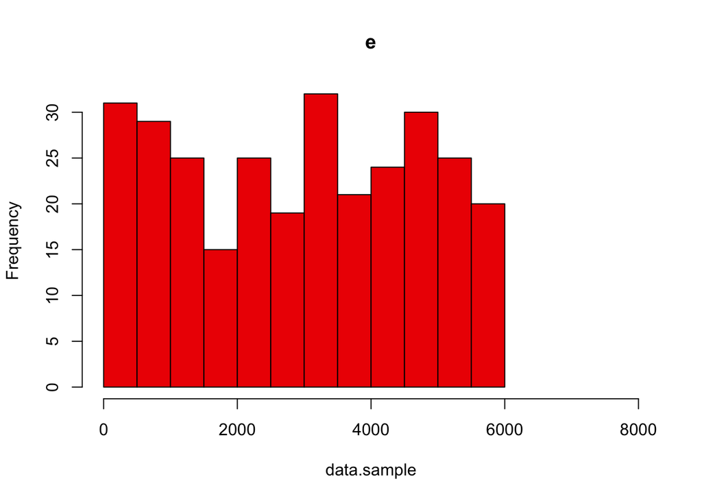

```r
data.sample <- sample.int(N, size=n, replace=FALSE)
eHistogram = hist(data.sample, xlim=c(0,8000), breaks=16, col='red2', main="e")
```

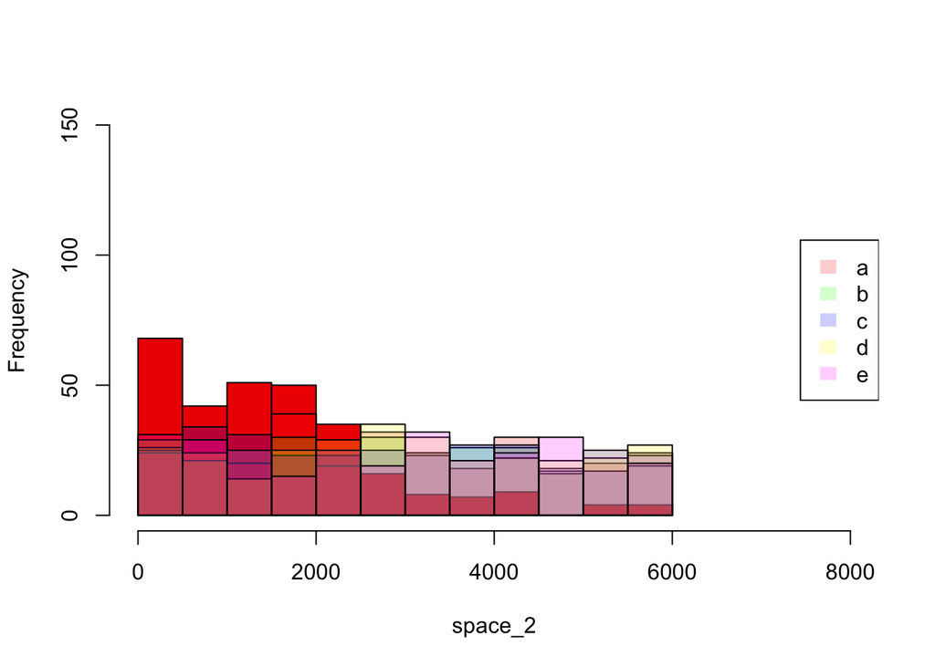

```r
aHistColor = rgb(1,0,0,0.2)
bHistColor = rgb(0,1,0,0.2)
cHistColor = rgb(0,0,1,0.2)
dHistColor = rgb(1,1,0,0.2)
eHistColor = rgb(1,0,1,0.2)

plot(hist_2, col='red2', ylim=c(0,150), xlim=c(0,8000), main=NA)
plot(aHistogram, col=aHistColor, ylim=c(0,150), xlim=c(0,8000), add=T)
plot(bHistogram, col=bHistColor, ylim=c(0,150), xlim=c(0,8000), add=T)
plot(cHistogram, col=cHistColor, ylim=c(0,150), xlim=c(0,8000), add=T)
plot(dHistogram, col=dHistColor, ylim=c(0,150), xlim=c(0,8000), add=T)
plot(eHistogram, col=eHistColor, ylim=c(0,150), xlim=c(0,8000), add=T)


legend('right', c('a', 'b', 'c', 'd', 'e'), fill=c(aHistColor, bHistColor, cHistColor, dHistColor, eHistColor), border=NA)
```

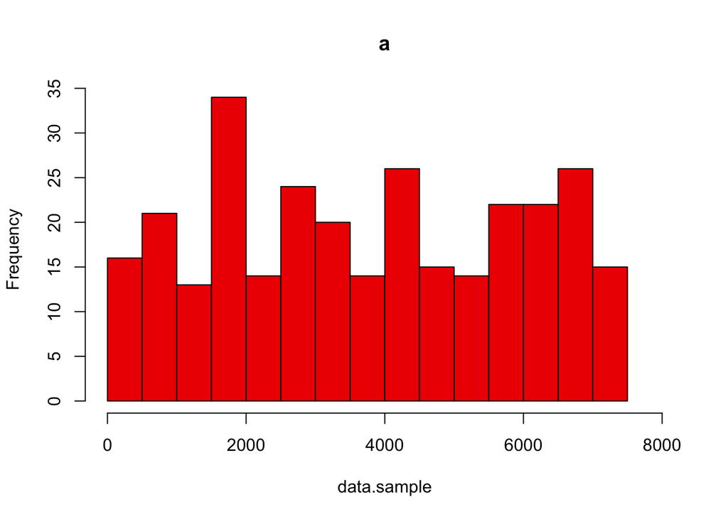

```r
N <- max(space_3, na.rm=TRUE)
n <- 296
gene <- seq(min(space_3, na.rm=TRUE), N)

set.seed(200)
data.sample <- sample.int(N, size=n, replace=FALSE)
aHistogram = hist(data.sample, xlim=c(0,8000), breaks=16, col='red2', main="a")
```

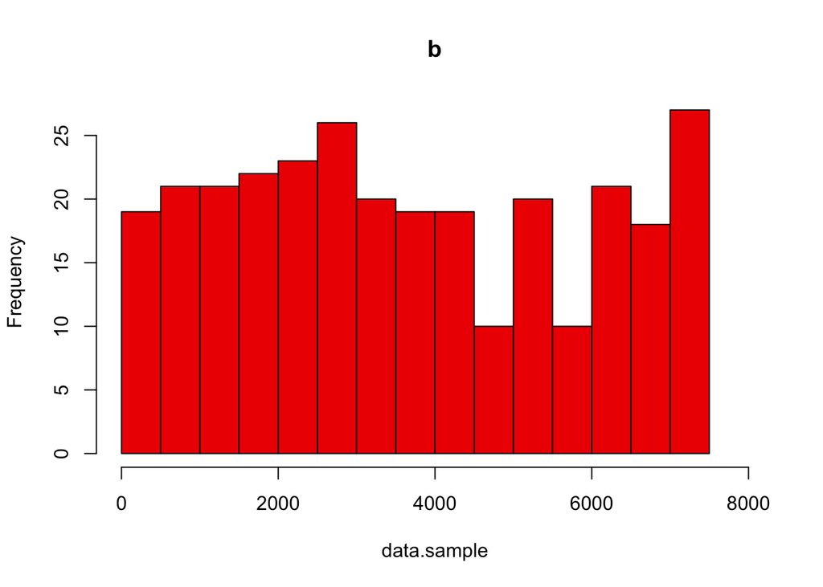

```r
data.sample <- sample.int(N, size=n, replace=FALSE)
bHistogram = hist(data.sample, xlim=c(0,8000), breaks=16, col='red2', main="b")
```